# S1_Informe

# **VAD msoffice**

- Esta variable tiene 896 respuestas válidas, una independiente de otra y tienen la misma probabilidad de ser seleccionadas.

Al considerarse que es una distribución binomial con parámetros n y P, el éxito será la probabilidad de que una laptop tenga ms office preinstalado con valor P, y fracaso que la laptop no tenga ms office preinstalado, con valor 1-P, y n la cantidad total de observaciones válidas, y n la cantidad total de observaciones válidas.

```
## [1] 0.322905
```

```
## [1] 289
```

```
## [1] 195.6804
```

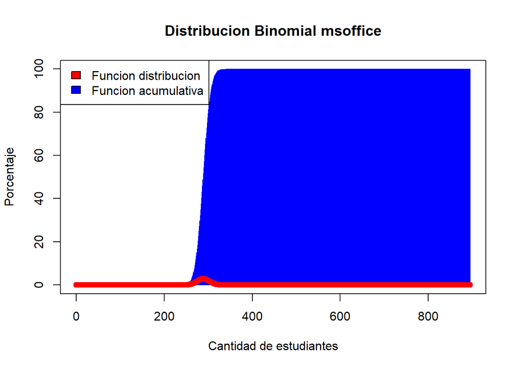

# **Variable Aleatoria Continua Tamaño de Pantalla**

- En la data obtenida tenemos 895 observaciones para el tamaño de pantalla de las laptops, una independiente de otra y de las cuales consideramos que tuvieron la misma probabilidad de ser seleccionadas por el consumidor.

Tamaños de pantalla presentes:

```
##  [1]    NA 15.60 14.00 13.30 14.20 16.20 13.00 14.10 17.30 13.40 16.00 14.96
## [13] 15.00 14.90 15.30 16.10 13.50 12.00 12.20
```

- Para el análisis de esta variable tomamos un rango aleatorio de 400 observaciones, definiendo la respectiva media y desviación estándar

```
##  [1]    NA 15.60 14.00 13.30 14.20 16.20 13.00 14.10 17.30 13.40 16.00 14.96
## [13] 15.00 14.90 15.30 16.10 13.50 12.00 12.20
```

```
## [1] 0.9823317
```

```
## [1] 14.7614
```

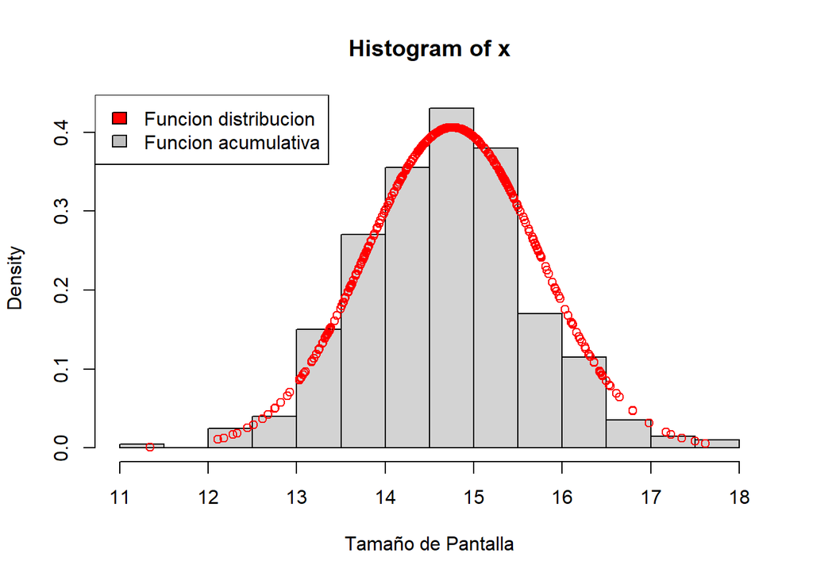

- De acuerdo al gráfico podemos ver que la mayor cantidad de pantallas se encuentran con un tamaño entre 13 y 16 pulgadas.

# **Variable aleatoria Discreta Marca**

- En la data obtenida tenemos 895 observaciones, una independiente de otra y de las cuales consideramos que tuvieron la misma probabilidad de ser seleccionadas por el consumidor.

```
##  [1] "acer"      "ALIENWARE" "APPLE"     "ASUS"      "Avita"     "DELL"
##  [7] "HP"        "Infinix"   "Lenovo"    "lenovo"    "LG"        "Mi"
## [13] "MICROSOFT" "MSI"       "Nokia"     "realme"    "RedmiBook" "SAMSUNG"
## [19] "Smartron"  "Vaio"
```

```
## [1] 0.2837989
```

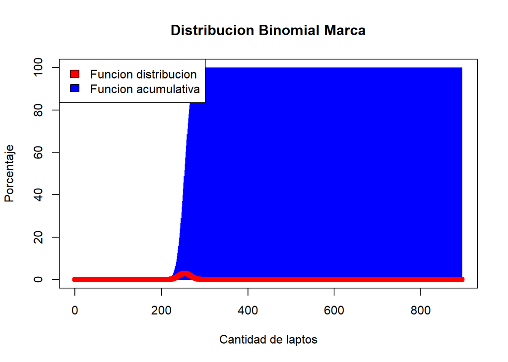

- Podemos observar que la probabilidad acumulada de encontrar laptops de marca ASUS tiene un comportamiento exponencial, cuanto más cerca nos encontramos del número total de laptops de marca ASUS

# **VAD Gb de Ram**

- La variable “Gb de Ram” esta recuperada de la base de datos Kaggle, donde los datos son indenpendientes y tienen la misma propabilidad de ser escogidos.
- CRITERIO PARA EL ANALISIS PROBABILISTICO: Se considero a la variable como una distribución de Poisson. En donde el éxitos es la persona que decidio comprar un ram mayor o igual a 8 Gb de ram y el fracaso a la persona que compro una ram menor a 8 Gb.Hallamos
  $$\lambda$$

$$E[X]= m_1 =
\sum_{x=0}^{\infty}x^{1}f(x)= \sum_{x=0}^{\infty}x \cdot e^{- \lambda}
\cdot \frac{\lambda^{x}}{x!} = \lambda$$
$$E[X^2]= m_2 = \sum_{x=0}^{\infty}x^{2} \cdot e^{-
\lambda} \cdot \frac{\lambda^{x}}{x!} = \lambda^2+\lambda$$
$$Var[X]= E[X^2] - (E[X])^2 =
(\lambda^2+\lambda) - (\lambda) = \lambda$$
$$Var[X]= \lambda$$